# análise-exploratária-2019

2024-08-09

```r
library(dplyr)
```

```r
library(tibble)
library(ggplot2)
library(corrplot)
library(FactoMineR)
library(factoextra)
```

# Carregamento e Preparação dos Dados

```r
ano_2019 <-read.csv("2019.csv")
store_final <-read.csv("store_final.csv")
target_store_final <-read.csv("target_store_final.csv")
sku_status_dataset <-read.csv2("sku_status_dataset.csv")
targets_salesperson_final <-read.csv("targets_salesperson_final.csv")
sku_price <-read.csv("sku_price.csv")
sku_dataset <-read.csv2("sku_dataset.csv")
sku_cost <-read.csv("sku_cost.csv")
employee_final <-read.csv("employee_final.csv")
```

# Descrição das Variáveis

Ano_2019 - data: Data da transação (Tipo: character) - cod_vendedor: Código identificador do vendedor (Tipo: numérico) - cod_loja: Código identificador da loja (Tipo: character) - cod_transacao: Código identificador da transação (Tipo: character) - quantidade: Quantidade de itens vendidos (Tipo: numérico) - cod_prod: Código identificador do produto (Tipo: numérico) - preco: Preço do produto (Tipo: numérico)

Store_final - nome_loja: Nome da loja (Tipo: character) - regiao: Região onde a loja está localizada (Tipo: character) - diretoria: Diretoria responsável pela loja (Tipo: character) - data_inauguracao: Data de inauguração da loja (Tipo: character)

Target_store_final - month: Mês da meta de vendas (Tipo: character) - store_id: Código identificador da loja (Tipo: character) - sales_target: Meta de vendas para a loja (Tipo: numérico)

Sku_status_dataset - cod_prod: Código identificador do produto (Tipo: numérico) - data_inicio: Data de início da validade do status do produto (Tipo: character) - data_fim: Data de fim da validade do status do produto (Tipo: character)

Targets_salesperson_final - id_employee: Código identificador do funcionário (Tipo: numérico) - sales_target: Meta de vendas para o funcionário (Tipo: numérico) - month: Mês da meta de vendas (Tipo: character)

Sku_price - cod_prod: Código identificador do produto (Tipo: numérico) - data_inicio: Data de início da validade do preço do produto (Tipo: character) - data_fim: Data de fim da validade do preço do produto (Tipo: character) - preco: Preço do produto (Tipo: numérico)

Sku_dataset - cod_prod: Código identificador do produto (Tipo: numérico) - nome_abrev: Nome abreviado do produto (Tipo: character) - nome_completo: Nome completo do produto (Tipo: character) - descricao: Descrição do produto (Tipo: character) - categoria: Categoria do produto (Tipo: character) - sub_categoria: Subcategoria do produto (Tipo: character) - marca: Marca do produto (Tipo: character) - conteudo_valor: Valor do conteúdo do produto (Tipo: character) - conteudo_medida: Medida do conteúdo do produto (Tipo: character)

Sku_cost - cod_prod: Código identificador do produto (Tipo: numérico) -data_inicio: Data de início da validade do custo do produto (Tipo: character) - data_fim: Data de fim da validade do custo do produto (Tipo: character) - custo: Custo do produto (Tipo: numérico)

Employee_final - id_employe: Código identificador do funcionário (Tipo: numérico) - name: Nome do funcionário (Tipo: character) - surname: Sobrenome do funcionário (Tipo: character) - cpf: CPF do funcionário (Tipo: character) - status: Status do funcionário (ativo/inativo) (Tipo: character) - role: Função/cargo do funcionário (Tipo: character) - initial_date: Data de início do contrato do funcionário (Tipo: character) - end_date: Data de término do contrato do funcionário (Tipo: character) - store_id: Código identificador da loja onde o funcionário trabalha (Tipo: character)

# Melhor visualização com tibble

```r
ano_2019 <- as_tibble(ano_2019)
store_final <- as_tibble(store_final)
target_store_final <- as_tibble(target_store_final)
sku_status_dataset <- as_tibble(sku_status_dataset)
targets_salesperson_final <- as_tibble(targets_salesperson_final)
sku_price <- as_tibble(sku_price)
sku_dataset <- as_tibble(sku_dataset)
sku_cost <- as_tibble(sku_cost)
employee_final <- as_tibble(employee_final)
```

# Exibir as primeiras linhas dos dados com melhor visualização

```r
print(head(ano_2019))
```

```
## # A tibble: 6 × 7
##   data       cod_vendedor cod_loja       cod_transacao quantidade cod_prod preco
##   <chr>             <int> <chr>          <chr>              <int>    <dbl> <dbl>
## 1 2019-12-24          146 MG_39          000137298c             4  6.31e11 887.
## 2 2019-12-28          106 SP Capital Ce… 0002abaa75             3  3.98e11 283.
## 3 2019-12-24          405 RS_21          00035d857f             1  8.14e11 416.
## 4 2019-12-26          954 SP Interior_42 0005f4ca31             3  1.52e11  53.3
## 5 2019-12-23          192 SP Capital Ce… 0006efa6df             6  2.77e11 584.
## 6 2019-12-23          192 SP Capital Ce… 0006efa6df             2  7.10e11 170.
```

```r
print(head(store_final))
```

```
## # A tibble: 6 × 4
##   nome_loja         regiao         diretoria data_inauguracao
##   <chr>             <chr>          <chr>     <chr>
## 1 SP Capital Sul_59 SP Capital Sul Grande SP 09/08/2020
## 2 SP Capital Sul_30 SP Capital Sul Grande SP 05/03/2000
## 3 SP Capital Sul_17 SP Capital Sul Grande SP 28/02/2019
## 4 SP Capital Sul_9  SP Capital Sul Grande SP 16/05/2001
## 5 SP Capital Sul_97 SP Capital Sul Grande SP 12/07/2017
## 6 SP Capital Sul_90 SP Capital Sul Grande SP 15/04/2000
```

```r
print(head(target_store_final))
```

```
## # A tibble: 6 × 3
##   month   store_id sales_target
##   <chr>   <chr>           <int>
## 1 01/2000 MG_21          116070
## 2 01/2000 MG_23          102199
## 3 01/2000 MG_24           98628
## 4 01/2000 MG_26          113215
## 5 01/2000 MG_29          113450
## 6 01/2000 MG_34          116066
```

```r
print(head(sku_status_dataset))
```

```
## # A tibble: 6 × 3
##       cod_prod data_inicio data_fim
##          <dbl> <chr>       <chr>
## 1 603078352615 2007-08-02  "2023-09-16"
## 2 131384024501 2006-08-22  "2020-05-12"
## 3  85873708529 2000-03-05  ""
## 4 579926605113 2011-05-05  "2018-06-23"
## 5 397769055946 2006-07-15  ""
## 6 981647487600 2021-04-02  ""
```

```r
print(head(targets_salesperson_final))
```

```
## # A tibble: 6 × 3
##   id_employee sales_target month
##         <int>        <int> <chr>
## 1         643        25088 01/2000
## 2         643        39703 02/2000
## 3         643        23478 03/2000
## 4         643        22417 04/2000
## 5         643        25622 05/2000
## 6         643        32298 06/2000
```

```r
print(head(sku_price))
```

```
## # A tibble: 6 × 4
##       cod_prod data_inicio data_fim   preco
##          <dbl> <chr>       <chr>      <dbl>
## 1 603078352615 2007-08-02  2009-08-07  26.0
## 2 603078352615 2009-08-08  2011-08-14  27.0
## 3 603078352615 2011-08-15  2013-08-20  28.0
## 4 603078352615 2013-08-21  2015-08-27  28.0
## 5 603078352615 2015-08-28  2017-09-02  29.0
## 6 603078352615 2017-09-03  2019-09-09  30.0
```

```r
print(head(sku_dataset))
```

```
## # A tibble: 6 × 9
##       cod_prod nome_abrev  nome_completo descricao categoria sub_categoria marca
##          <dbl> <chr>       <chr>         <chr>     <chr>     <chr>         <chr>
## 1 603078352615 Acne Solut… Acne Solutio… Sabonete… Corpo     Sabonete líq… Clin…
## 2 131384024501 Pep Start … Pep Start Da… Protetor… Corpo     Protetor sol… Clin…
## 3  85873708529 Deep Comfo… Deep Comfort… Sabonete… Corpo     Sabonete líq… Clin…
## 4 579926605113 Lipikar Wa… Lipikar Wash… Sabonete… Corpo     Sabonete líq… La R…
## 5 397769055946 Anthelios … Anthelios AO… Protetor… Corpo     Protetor sol… La R…
## 6 981647487600 Basil Whit… Basil & Whit… Sabonete… Corpo     Sabonete líq… Nivea
## # ℹ 2 more variables: conteudo_valor <chr>, conteudo_medida <chr>
```

```r
print(head(sku_cost))
```

```
## # A tibble: 6 × 4
##       cod_prod data_inicio data_fim   custo
##          <dbl> <chr>       <chr>      <dbl>
## 1 603078352615 2007-08-02  2011-08-13  26.2
## 2 603078352615 2011-08-14  2015-08-25  27.1
## 3 603078352615 2015-08-26  2019-09-06  27.5
## 4 603078352615 2019-09-07  2023-09-16  27.6
## 5 131384024501 2006-08-22  2009-05-20  70.8
## 6 131384024501 2009-05-21  2012-02-17  71.6
```

```r
print(head(employee_final))
```

```
## # A tibble: 6 × 9
##   id_employee name     surname cpf   status role  initial_date end_date store_id
##         <int> <chr>    <chr>   <chr> <chr>  <chr> <chr>        <chr>    <chr>
## 1         643 Antonel… da Cruz 938.… ativo  gere… 14/12/2007   ""       MG_21
## 2         924 Carlos … Alves   501.… ativo  vend… 29/09/2014   ""       MG_21
## 3         567 Ana Sop… Ramos   980.… ativo  vend… 03/04/2006   ""       MG_21
## 4         660 Marcela  Brito   859.… ativo  vend… 14/03/2003   ""       MG_21
## 5         297 Leonardo Porto   652.… ativo  vend… 27/06/2021   ""       MG_23
## 6         523 Heitor   Sales   472.… ativo  vend… 11/09/2021   ""       MG_23
```

# Verificar a estrutura dos dados

```r
str(ano_2019)
```

```
## tibble [4,738,531 × 7] (S3: tbl_df/tbl/data.frame)
##  $ data         : chr [1:4738531] "2019-12-24" "2019-12-28" "2019-12-24" "2019-12-26" ...
##  $ cod_vendedor : int [1:4738531] 146 106 405 954 192 192 849 849 325 138 ...
##  $ cod_loja     : chr [1:4738531] "MG_39" "SP Capital Centro_92" "RS_21" "SP Interior_42" ...
##  $ cod_transacao: chr [1:4738531] "000137298c" "0002abaa75" "00035d857f" "0005f4ca31" ...
##  $ quantidade   : int [1:4738531] 4 3 1 3 6 2 2 2 4 3 ...
##  $ cod_prod     : num [1:4738531] 6.31e+11 3.98e+11 8.14e+11 1.52e+11 2.77e+11 ...
##  $ preco        : num [1:4738531] 887 283.5 416.4 53.3 583.8 ...
```

```r
str(store_final)
```

```
## tibble [205 × 4] (S3: tbl_df/tbl/data.frame)
##  $ nome_loja       : chr [1:205] "SP Capital Sul_59" "SP Capital Sul_30" "SP Capital Sul_17" "SP Capital Sul_9" ...
##  $ regiao          : chr [1:205] "SP Capital Sul" "SP Capital Sul" "SP Capital Sul" "SP Capital Sul" ...
##  $ diretoria       : chr [1:205] "Grande SP" "Grande SP" "Grande SP" "Grande SP" ...
##  $ data_inauguracao: chr [1:205] "09/08/2020" "05/03/2000" "28/02/2019" "16/05/2001" ...
```

```r
str(target_store_final)
```

```
## tibble [61,500 × 3] (S3: tbl_df/tbl/data.frame)
##  $ month       : chr [1:61500] "01/2000" "01/2000" "01/2000" "01/2000" ...
##  $ store_id    : chr [1:61500] "MG_21" "MG_23" "MG_24" "MG_26" ...
##  $ sales_target: int [1:61500] 116070 102199 98628 113215 113450 116066 133941 116652 110423 134822 ...
```

```r
str(sku_status_dataset)
```

```
## tibble [563 × 3] (S3: tbl_df/tbl/data.frame)
##  $ cod_prod   : num [1:563] 6.03e+11 1.31e+11 8.59e+10 5.80e+11 3.98e+11 ...
##  $ data_inicio: chr [1:563] "2007-08-02" "2006-08-22" "2000-03-05" "2011-05-05" ...
##  $ data_fim   : chr [1:563] "2023-09-16" "2020-05-12" "" "2018-06-23" ...
```

```r
str(targets_salesperson_final)
```

```
## tibble [246,000 × 3] (S3: tbl_df/tbl/data.frame)
##  $ id_employee : int [1:246000] 643 643 643 643 643 643 643 643 643 643 ...
##  $ sales_target: int [1:246000] 25088 39703 23478 22417 25622 32298 37406 26462 21400 35700 ...
##  $ month       : chr [1:246000] "01/2000" "02/2000" "03/2000" "04/2000" ...
```

```r
str(sku_price)
```

```
## tibble [5,323 × 4] (S3: tbl_df/tbl/data.frame)
##  $ cod_prod   : num [1:5323] 6.03e+11 6.03e+11 6.03e+11 6.03e+11 6.03e+11 ...
##  $ data_inicio: chr [1:5323] "2007-08-02" "2009-08-08" "2011-08-15" "2013-08-21" ...
##  $ data_fim   : chr [1:5323] "2009-08-07" "2011-08-14" "2013-08-20" "2015-08-27" ...
##  $ preco      : num [1:5323] 26 27 28 28 29 ...
```

```r
str(sku_dataset)
```

```
## tibble [563 × 9] (S3: tbl_df/tbl/data.frame)
##  $ cod_prod       : num [1:563] 6.03e+11 1.31e+11 8.59e+10 5.80e+11 3.98e+11 ...
##  $ nome_abrev     : chr [1:563] "Acne Solutions Cleansing Bar" "Pep Start Daily UV" "Deep Comfort Body Wash" "Lipikar Wash Gentle Foaming" ...
##  $ nome_completo  : chr [1:563] "Acne Solutions Cleansing Bar for Face & Body" "Pep Start Daily UV Protector Broad Spectrum SPF 50" "Deep Comfort Body Wash" "Lipikar Wash AP+ Gentle Foaming Moisturizing Wash" ...
##  $ descricao      : chr [1:563] "Sabonete líquido Clinique Acne Solutions Cleansing Bar for Face & Body  para Corpo" "Protetor solar Clinique Pep Start Daily UV Protector Broad Spectrum SPF 50  para Corpo" "Sabonete líquido Clinique Deep Comfort Body Wash  para Corpo" "Sabonete líquido La Roche-P…
##  $ categoria      : chr [1:563] "Corpo" "Corpo" "Corpo" "Corpo" ...
##  $ sub_categoria  : chr [1:563] "Sabonete líquido" "Protetor solar" "Sabonete líquido" "Sabonete líquido" ...
##  $ marca          : chr [1:563] "Clinique" "Clinique" "Clinique" "La Roche-Posay" ...
##  $ conteudo_valor : chr [1:563] "156.0" "30.0" "204.0" "405.0" ...
##  $ conteudo_medida: chr [1:563] "ml" "ml" "ml" "ml" ...
```

```r
str(sku_cost)
```

```
## tibble [2,235 × 4] (S3: tbl_df/tbl/data.frame)
##  $ cod_prod   : num [1:2235] 6.03e+11 6.03e+11 6.03e+11 6.03e+11 1.31e+11 ...
##  $ data_inicio: chr [1:2235] "2007-08-02" "2011-08-14" "2015-08-26" "2019-09-07" ...
##  $ data_fim   : chr [1:2235] "2011-08-13" "2015-08-25" "2019-09-06" "2023-09-16" ...
##  $ custo      : num [1:2235] 26.2 27.1 27.5 27.6 70.8 ...
```

```r
str(employee_final)
```

```
## tibble [920 × 9] (S3: tbl_df/tbl/data.frame)
##  $ id_employee : int [1:920] 643 924 567 660 297 523 264 834 693 417 ...
##  $ name        : chr [1:920] "Antonella" "Carlos Eduardo" "Ana Sophia" "Marcela" ...
##  $ surname     : chr [1:920] "da Cruz" "Alves" "Ramos" "Brito" ...
##  $ cpf         : chr [1:920] "938.507.461-00" "501.639.827-59" "980.413.526-42" "859.163.742-91" ...
##  $ status      : chr [1:920] "ativo" "ativo" "ativo" "ativo" ...
##  $ role        : chr [1:920] "gerente" "vendedor" "vendedor" "vendedor" ...
##  $ initial_date: chr [1:920] "14/12/2007" "29/09/2014" "03/04/2006" "14/03/2003" ...
##  $ end_date    : chr [1:920] "" "" "" "" ...
##  $ store_id    : chr [1:920] "MG_21" "MG_21" "MG_21" "MG_21" ...
```

# Resumo estatístico das variáveis

```r
summary(ano_2019)
```

```
##      data            cod_vendedor     cod_loja         cod_transacao
##  Length:4738531     Min.   :  2.0   Length:4738531     Length:4738531
##  Class :character   1st Qu.:246.0   Class :character   Class :character
##  Mode  :character   Median :484.0   Mode  :character   Mode  :character
##                     Mean   :492.2
##                     3rd Qu.:747.0
##                     Max.   :997.0
##    quantidade       cod_prod             preco
##  Min.   :1.000   Min.   :8.312e+09   Min.   :  10.18
##  1st Qu.:2.000   1st Qu.:2.488e+11   1st Qu.:  96.03
##  Median :4.000   Median :4.743e+11   Median : 191.39
##  Mean   :3.746   Mean   :5.070e+11   Mean   : 321.25
##  3rd Qu.:5.000   3rd Qu.:7.755e+11   3rd Qu.: 358.17
##  Max.   :8.000   Max.   :9.970e+11   Max.   :3981.94
```

```r
summary(store_final)
```

```
##   nome_loja            regiao           diretoria         data_inauguracao
##  Length:205         Length:205         Length:205         Length:205
##  Class :character   Class :character   Class :character   Class :character
##  Mode  :character   Mode  :character   Mode  :character   Mode  :character
```

```r
summary(target_store_final)
```

```
##     month             store_id          sales_target
##  Length:61500       Length:61500       Min.   : 83260
##  Class :character   Class :character   1st Qu.:111964
##  Mode  :character   Mode  :character   Median :120030
##                                        Mean   :120061
##                                        3rd Qu.:128116
##                                        Max.   :157485
```

```r
summary(sku_status_dataset)
```

```
##     cod_prod         data_inicio          data_fim
##  Min.   :6.587e+09   Length:563         Length:563
##  1st Qu.:2.506e+11   Class :character   Class :character
##  Median :4.800e+11   Mode  :character   Mode  :character
##  Mean   :5.024e+11
##  3rd Qu.:7.696e+11
##  Max.   :9.970e+11
```

```r
summary(targets_salesperson_final)
```

```
##   id_employee      sales_target      month
##  Min.   :   1.0   Min.   :20000   Length:246000
##  1st Qu.: 249.8   1st Qu.:25014   Class :character
##  Median : 490.5   Median :30047   Mode  :character
##  Mean   : 497.6   Mean   :30015
##  3rd Qu.: 752.2   3rd Qu.:35000
##  Max.   :1000.0   Max.   :40000
```

```r
summary(sku_price)
```

```
##     cod_prod         data_inicio          data_fim             preco
##  Min.   :6.587e+09   Length:5323        Length:5323        Min.   :  9.99
##  1st Qu.:2.504e+11   Class :character   Class :character   1st Qu.: 35.99
##  Median :4.952e+11   Mode  :character   Mode  :character   Median : 57.99
##  Mean   :5.038e+11                                         Mean   : 93.55
##  3rd Qu.:7.719e+11                                         3rd Qu.: 94.99
##  Max.   :9.970e+11                                         Max.   :550.99
```

```r
summary(sku_dataset)
```

```
##     cod_prod          nome_abrev        nome_completo       descricao
##  Min.   :6.587e+09   Length:563         Length:563         Length:563
##  1st Qu.:2.506e+11   Class :character   Class :character   Class :character
##  Median :4.800e+11   Mode  :character   Mode  :character   Mode  :character
##  Mean   :5.024e+11
##  3rd Qu.:7.696e+11
##  Max.   :9.970e+11
##   categoria         sub_categoria         marca           conteudo_valor
##  Length:563         Length:563         Length:563         Length:563
##  Class :character   Class :character   Class :character   Class :character
##  Mode  :character   Mode  :character   Mode  :character   Mode  :character
##
##
##
##  conteudo_medida
##  Length:563
##  Class :character
##  Mode  :character
##
##
##
```

```r
summary(sku_cost)
```

```
##     cod_prod         data_inicio          data_fim             custo
##  Min.   :6.587e+09   Length:2235        Length:2235        Min.   :  6.35
##  1st Qu.:2.472e+11   Class :character   Class :character   1st Qu.: 22.89
##  Median :4.797e+11   Mode  :character   Mode  :character   Median : 33.96
##  Mean   :4.983e+11                                         Mean   : 68.34
##  3rd Qu.:7.689e+11                                         3rd Qu.: 64.93
##  Max.   :9.970e+11                                         Max.   :414.07
```

```r
summary(employee_final)
```

```
##   id_employee         name             surname              cpf
##  Min.   :   1.0   Length:920         Length:920         Length:920
##  1st Qu.: 248.8   Class :character   Class :character   Class :character
##  Median : 492.5   Mode  :character   Mode  :character   Mode  :character
##  Mean   : 497.5
##  3rd Qu.: 750.2
##  Max.   :1000.0
##     status              role           initial_date         end_date
##  Length:920         Length:920         Length:920         Length:920
##  Class :character   Class :character   Class :character   Class :character
##  Mode  :character   Mode  :character   Mode  :character   Mode  :character
##
##
##
##    store_id
##  Length:920
##  Class :character
##  Mode  :character
##
##
##
```

# Histograma para a variável quantidade

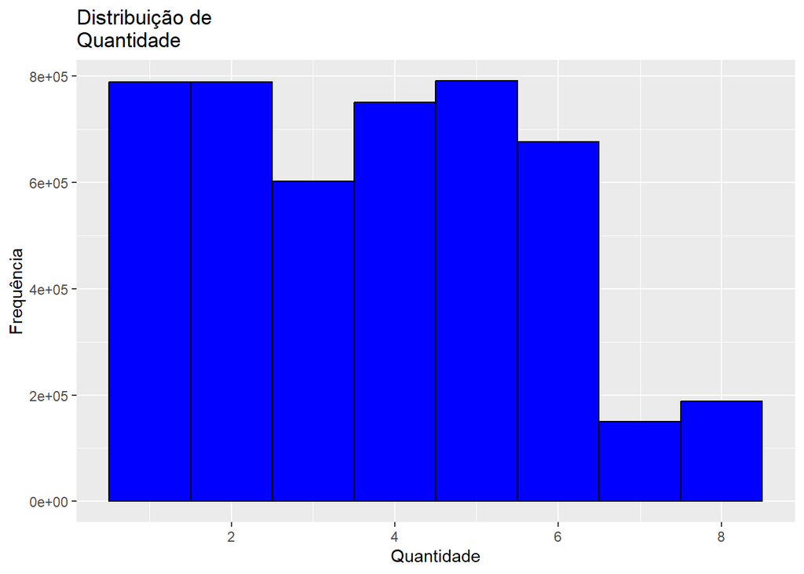

```r
ggplot(ano_2019, aes(x = quantidade)) + geom_histogram(binwidth = 1,
fill = "blue", color = "black") + labs(title = "Distribuição de
Quantidade", x = "Quantidade", y = "Frequência")
```

# Gráfico de densidade para a variável preço

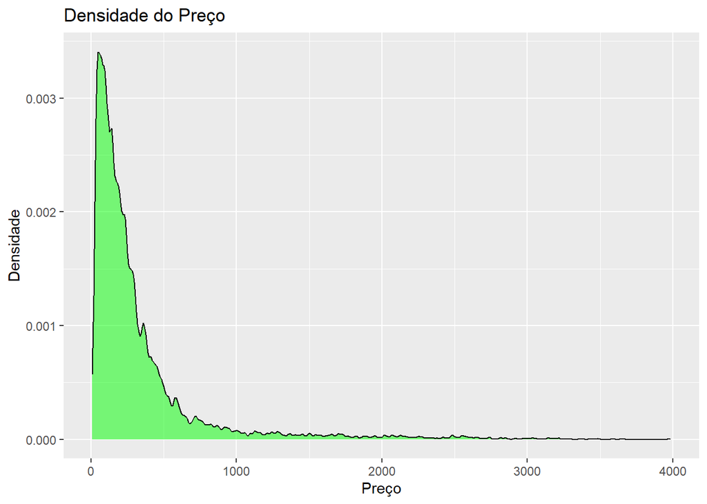

```r
ggplot(ano_2019, aes(x = preco)) + geom_density(fill = "green", alpha =
0.5) + labs(title = "Densidade do Preço", x = "Preço", y = "Densidade")
```

# Gráfico de barras para a variável regiao

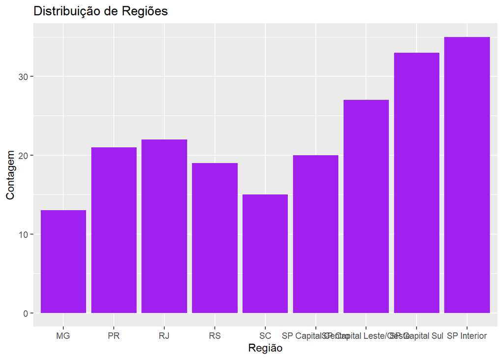

```r
ggplot(store_final, aes(x = regiao)) + geom_bar(fill = "purple") +
labs(title = "Distribuição de Regiões", x = "Região", y = "Contagem")
```

# Gráfico de barras de venda por região

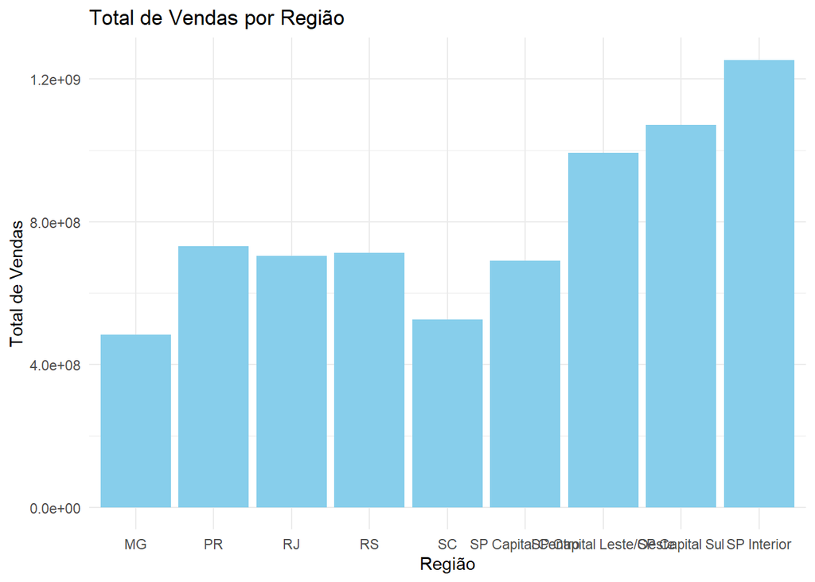

```r
vendas_regiao <- ano_2019 %>%
  left_join(store_final, by = c("cod_loja" = "nome_loja")) %>%
  group_by(regiao) %>%
  summarise(total_vendas = sum(quantidade * preco, na.rm = TRUE))

ggplot(vendas_regiao, aes(x = regiao, y = total_vendas)) +
  geom_bar(stat = "identity", fill = "skyblue") +
  labs(title = "Total de Vendas por Região", x = "Região", y = "Total de Vendas") +
  theme_minimal()
```

# Gráfico de densidade para a variável custo

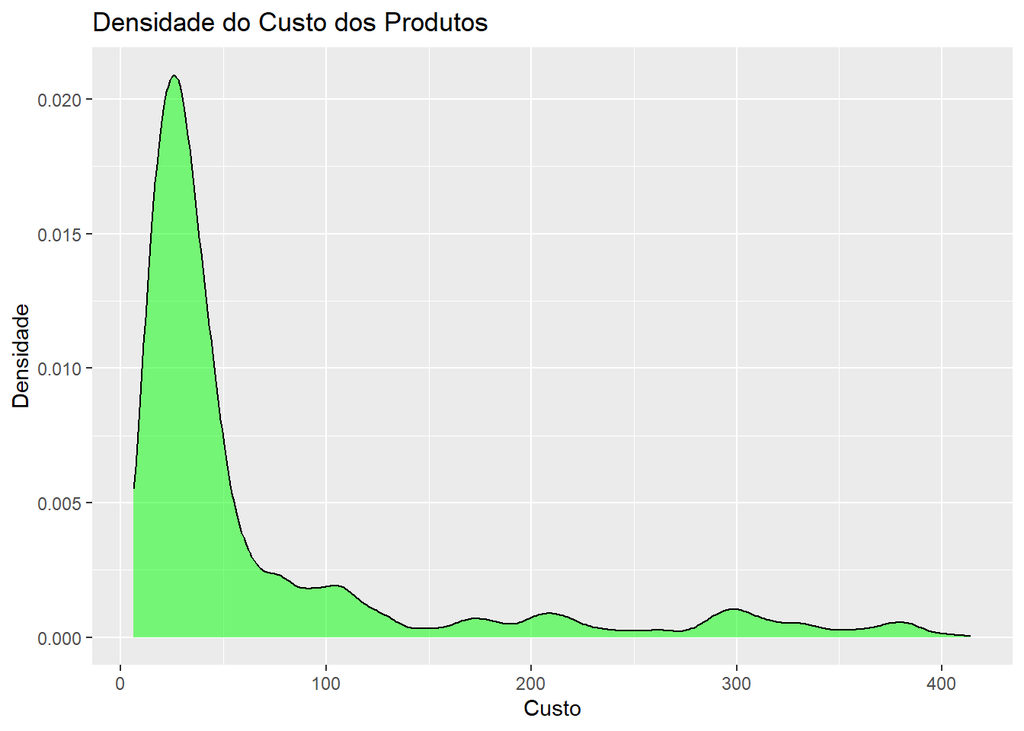

```r
ggplot(sku_cost, aes(x = custo)) + geom_density(fill = "green", alpha =
0.5) + labs(title = "Densidade do Custo dos Produtos", x = "Custo", y =
"Densidade")
```

# Correlação entre Preço e Custo dos Produtos

```r
preco_custo <- sku_price %>%
  inner_join(sku_cost, by = "cod_prod") %>%
  group_by(cod_prod) %>%
  summarise(preco_medio = mean(preco, na.rm = TRUE), custo_medio = mean(custo, na.rm = TRUE))
```

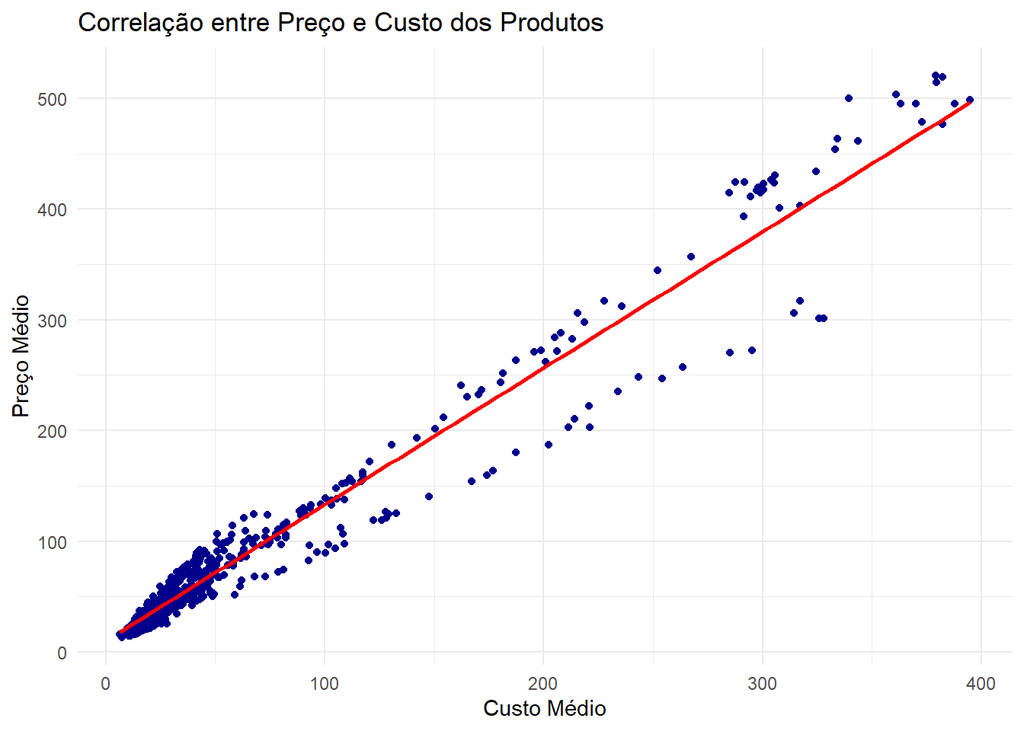

```r
ggplot(preco_custo, aes(x = custo_medio, y = preco_medio)) +
  geom_point(color = "darkblue") +
  geom_smooth(method = "lm", color = "red", se = FALSE) +
  labs(title = "Correlação entre Preço e Custo dos Produtos", x = "Custo Médio", y = "Preço Médio") +
  theme_minimal()
```

```r
cor(preco_custo$preco_medio, preco_custo$custo_medio, use = "complete.obs")
```

```
## [1] 0.9789456
```

# Histograma para a variável sales_target

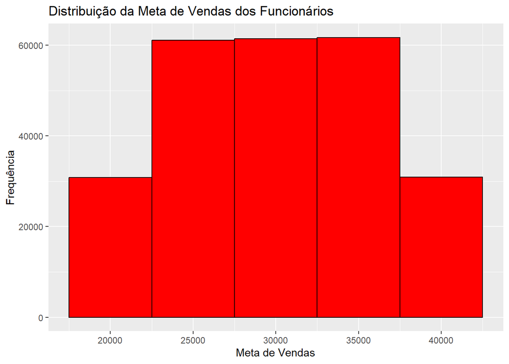

```r
ggplot(targets_salesperson_final, aes(x = sales_target)) +
geom_histogram(binwidth = 5000, fill = "red", color = "black") +
labs(title = "Distribuição da Meta de Vendas dos Funcionários", x =
"Meta de Vendas", y = "Frequência")
```